# Netcdf data analysis

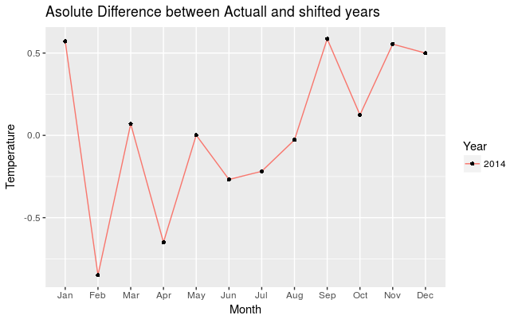

```r
dts_shifted <- seq(as.Date("2014/1/1"), by = "month", length.out = 12)
mean_monthly_Total <- c (shifte_second_year - mean_monthly_second)
temp_compare <- data.frame(Temprature = c(mean_monthly_Total), Dates = dts_shifted)
Temps_per_day <- transform(temp_compare,
                           Year = format(Dates, '%Y'),
                           MonthOfYear = as.numeric(format(Dates, '%m')),
                           Temprature = Temprature)
ggplot(Temps_per_day, aes(MonthOfYear, Temprature)) +
  geom_line( aes(colour = Year)) + geom_point( aes(shape = Year)) +
  scale_x_discrete(limits = All_Months) +
  labs(title = "Asolute Difference between Actuall and shifted years") +
  labs(x = "Month") +
  labs(y = "Temperature")
```

Is there a difference to Tokio (35.6895° N, 139.6917° E)? Unlike Hamburg, Tokyo seems to have a mixed weather over the years. No year is the coldest or the warmest.

```r
monthly <- matrix(c(temp[187,74,]),nrow = 30,ncol = 36)
```

```
data length [1096] is not a sub-multiple or multiple of the number of rows [30]
```

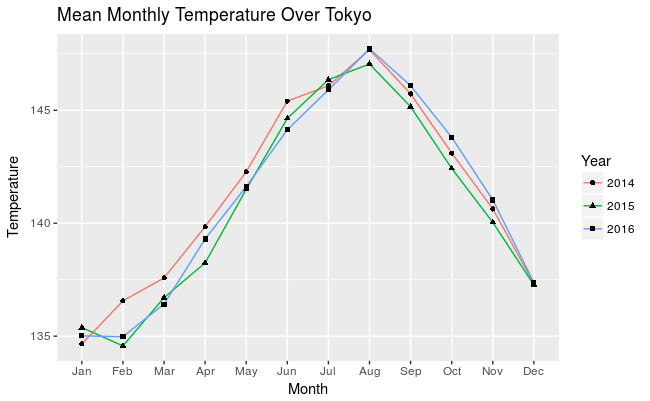

```r
mean_monthly <- colMeans(monthly, na.rm = TRUE)
mean_monthly <- (mean_monthly-32) * 0.5556
temp_hamburg <- data.frame(Temprature = c(mean_monthly), Dates = dts)
Temps_per_day <- transform(temp_hamburg,
                           Year = format(Dates, '%Y'),
                           MonthOfYear = as.numeric(format(Dates, '%m')),
                           Temprature = Temprature)
# hist(temp_hamburg)
ggplot(Temps_per_day, aes(MonthOfYear, Temprature)) +
  geom_line( aes(colour = Year)) + geom_point( aes(shape = Year)) +
  scale_x_discrete(limits = All_Months) +
  labs(title = "Mean Monthly Temperature Over Tokyo") +
  labs(x = "Month") +
  labs(y = "Temperature")
```

Is there a correlation between temperature, precipitation and sun duration? For this question all the data for the 3 metrics have been loaded into vector, and the correlations were calculated for them. No apparent linear correlation have been detected which seems counter intuitive. For plots partial set of the actual data have been used to avoid long time in rendering.

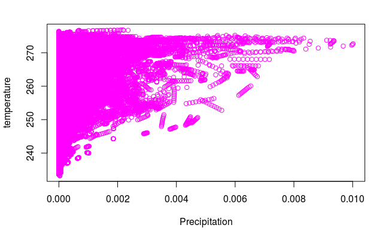

```r
vector_of_temperature <- c(temp[1:10,1:10,])
vector_of_precipitation <- c( ncvar_get(ncin,"tp")[1:10,1:10,])
vector_of_sun_duration <- c( ncvar_get(ncin,"sund")[1:10,1:10,])
temperature <- c(temp[,,])
precipitation <- c( ncvar_get(ncin,"tp")[,,])
sun_duration <- c( ncvar_get(ncin,"sund")[,,])
plot(vector_of_precipitation, vector_of_temperature, pch = 1, xlab = "Precipitation",
     ylab = "temperature", col = 14)
```

```r
cor(precipitation,temperature, method = "pearson")
```

```
[1] 0.1892052
```

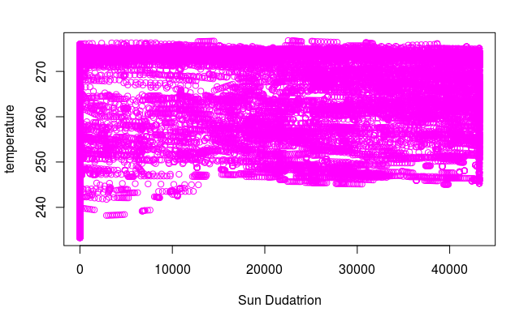

```r
plot(vector_of_sun_duration, vector_of_temperature, pch = 1, xlab = "Sun Dudatrion",
     ylab = "temperature", col = 14)
```

```r
cor(sun_duration,temperature, method = "pearson")
```

```
[1] 0.2361691
```

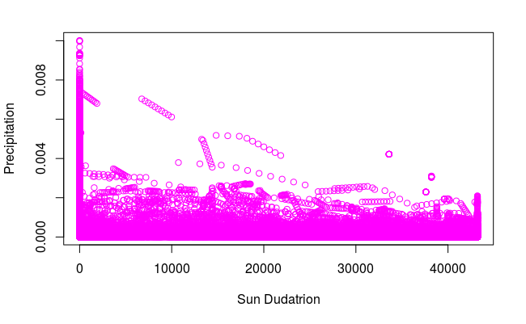

```r
plot(vector_of_sun_duration, vector_of_precipitation, pch = 1, xlab = "Sun Dudatrion",
     ylab = "Precipitation", col = 14)
```